# An Introduction to rtweet: Getting & Analyzing Data from the Twitter API

2020/03/28

## Topics

1. About Me
2. rtweet
3. The Twitter API
4. `search_tweets()`
5. `get_trends()`
6. `stream_tweets()`
7. Social Network Analysis - `get_friends() get_followers()`
8. `get_timelines()`
9. `get_favorites()`
10. But wait! There’s more!

## About Me

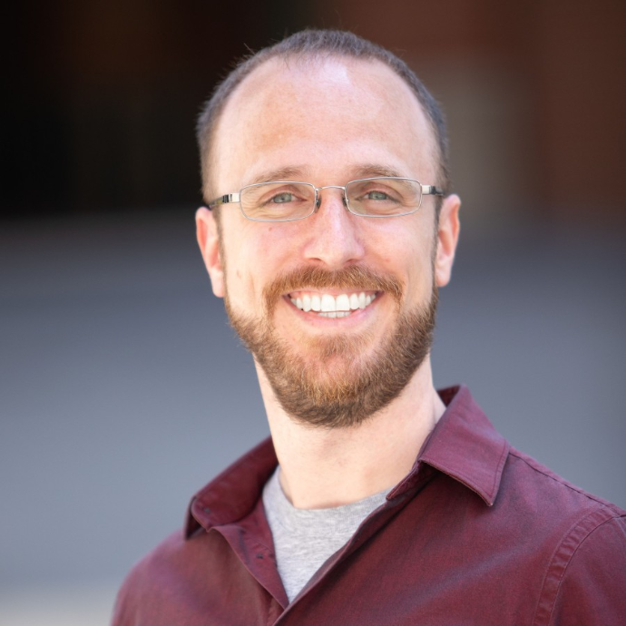

- Social Scientist by Training
  - Psychology & Music `%>%`
  - More Psychlogy `%>%`
  - Law & Policy
- Higher Education Analyst by Trade
- R User by Stumbling
  - Excel `%>%`
  - SPSS GUI `%>%`
  - SPSS Syntax `%>%`
  - SQL `%>%`
  - R

## rtweet

[figure not shown]

- [rtweet Vignette - https://rtweet.info/](https://rtweet.info/)
- Developed & maintained by [@kearneymw](https://twitter.com/kearneymw)
- An implementation of calls designed to collect and organize Twitter data via Twitter’s REST and stream Application Program Interfaces (API), which can be found at the following URL:  
  https://developer.twitter.com/en/docs.

## The Twitter API

- No longer need a Twitter developer account
  - Walthrough [available](https://rtweet.info/articles/auth.html) for developer accounts
- You *DO* need a Twitter account
- Authorize API by calling an `rtweet` function like `search_tweets()`
- Twitter API limits 18,000 results / 15 min
  - `retryonratelimit = TRUE`
- Must be used in accordance with [Twitter’s developer terms](https://developer.twitter.com/en/docs/tweets/data-dictionary/overview/tweet-object)

## Tweeting with rtweet

[figure not shown]

```r
post_tweet(
  status = "Hey @Satrdays_DC, did you know you can
            post a Tweet directly from #rstats?",
  media = "images/no_way.gif"
)
```

https://memecrunch.com/meme/C0QML/no-way

## `search_tweets()`

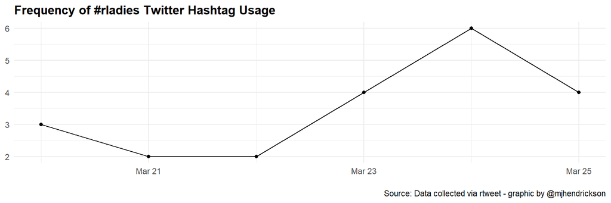

```r
search_tweets("#rladies", n = 5000, include_rts = FALSE) %>%
ts_plot("days", trim = 1L) +
  geom_point() + theme_minimal() +
  theme(plot.title = element_text(face = "bold")) +
  labs(x = NULL,  y = NULL,
    title = "Frequency of #rladies Twitter Hashtag Usage",
    caption = "\nSource: Data collected via rtweet - graphic by @mjhendrickson")
```

## `get_trends()`

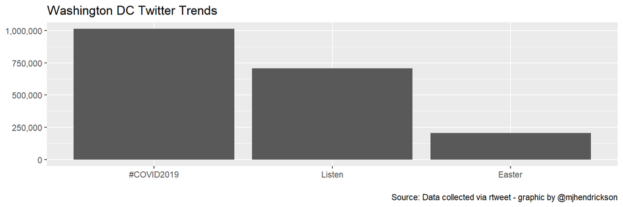

```r
get_trends("washington") %>% # trends_available() to see locales
  top_n(3, tweet_volume) %>% # Pull top 3 trends by volume
ggplot() +
  geom_bar(mapping = aes(x = reorder(trend, -tweet_volume), y = tweet_volume), stat = "identity") +
  scale_y_continuous(labels = comma) +
  theme(axis.title.x = element_blank()) +
  theme(axis.title.y = element_blank()) +
  labs(title = "Washington DC Twitter Trends",
       caption = "\nSource: Data collected via rtweet - graphic by @mjhendrickson")
```

## `stream_tweets()`

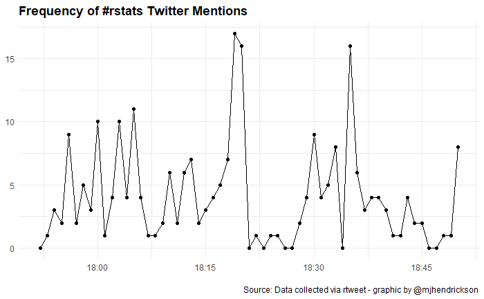

```r
rstats <- stream_tweets("rstats", timeout = 60 * 60) # = 60 min
rstats %>%
ts_plot("mins", trim = 1L) +
  geom_point() + theme_minimal() +
  theme(plot.title = element_text(face = "bold")) +
  labs(x = NULL,  y = NULL,
    title = "Frequency of #rstats Twitter Mentions",
    caption = "\nSource: Data collected via rtweet - graphic by @mjhendrickson")
```

## Social Network Analysis

```r
# Get list of friends
friends        <- get_friends(c("mjhendrickson", "kearneymw", "LittleMissData", "AnnaHenschel"))

# Get screen names for friends
friends_names  <- lookup_users(friends$user_id)

# Add screen names to friends data
friends_list   <- left_join(friends, friends_names)
friends_list   <- friends_list[, c("user", "screen_name")]

# Count of accounts followed by users
friends_data   <- table(friends_list$screen_name)

# User overlap
friends_trim   <- subset(friends_list, screen_name %in% names(friends_data[friends_data >2L]))

# Create matrix
friends_matrix <- as.matrix(friends_trim)

# Plot SNA
plot(graph_from_edgelist(friends_matrix), vertex.color = "grey", vertex.label.color = "black",
     vertex.label.cex = .75, edge.curved = .25, edge.color = "grey20", arrow.size = 5, arrow.width = .25)
```

## Social Network Analysis Output

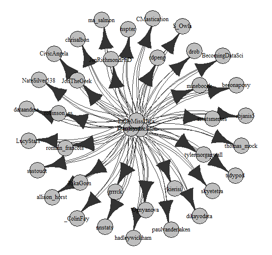

## `get_timelines()`

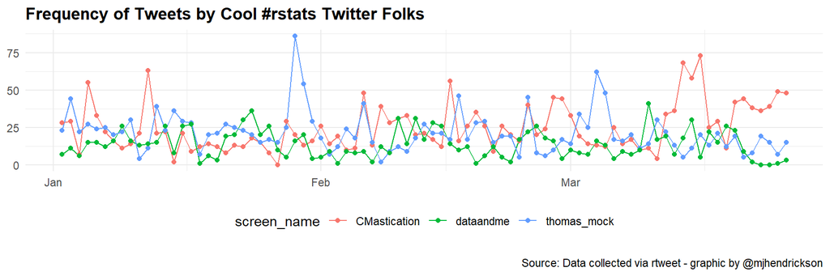

```r
get_timelines(c("dataandme", "thomas_mock", "CMastication"), n = 5000) %>%
  filter(created_at > "2020-01-01") %>% group_by(screen_name) %>%
ts_plot("days", trim = 1L) +
  geom_point() + theme_minimal() +
  theme(legend.position = "bottom",
    plot.title = element_text(face = "bold")) +
  labs(x = NULL, y = NULL,
    title = "Frequency of Tweets by Cool #rstats Twitter Folks",
    caption = "\nSource: Data collected via rtweet - graphic by @mjhendrickson")
```

## `get_favorites()`

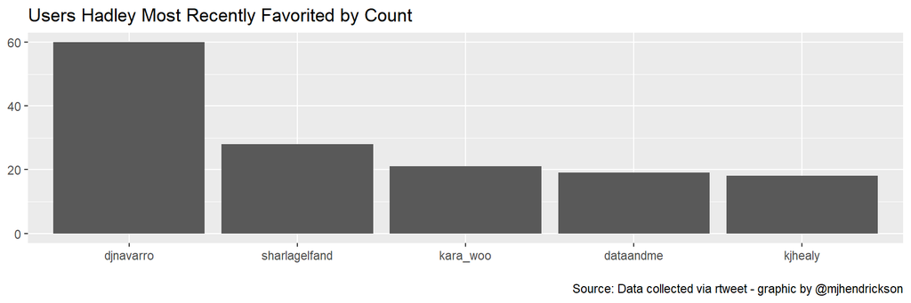

```r
hadley_favs <- get_favorites('hadleywickham', n = 1000)
hadley_fav_count <- hadley_favs %>% group_by(screen_name) %>% summarize(n = n()) %>% arrange(desc(n))
hadley_fav_count %>% top_n(5, n) %>%
ggplot() +
  geom_col(mapping = aes(x = fct_reorder(screen_name, -n), y = n)) +
  scale_y_continuous(labels = comma) +
  theme(axis.title.x = element_blank()) +
  theme(axis.title.y = element_blank()) +
  labs(title = "Users Hadley Most Recently Favorited by Count",
       caption = "\nSource: Data collected via rtweet - graphic by @mjhendrickson")
```

## Upset Plot

```r
# Credit to @PaulCampbell91 for the borrowed code
rstaters <- c("mjhendrickson", "CMastication", "thomas_mock", "kearneymw", "LittleMissData", "AnnaHenschel")

followers_upset <- map_df(rstaters, ~ get_followers(.x, n=100000, retryonratelimit = TRUE) %>%
                          mutate(account = .x))

aRdent_followers <- unique(followers_upset$user_id)

binaries <- rstaters %>%
  map_dfc(~ ifelse(aRdent_followers %in% filter(followers_upset, account == .x)$user_id, 1, 0) %>%
            as.data.frame)

names(binaries) <- rstaters

upset(binaries,
      nsets = 6,
      main.bar.color = "SteelBlue",
      sets.bar.color = "DarkCyan",
      sets.x.label = "Follower Count",
      text.scale = c(rep(1.4, 5), 1),
      order.by = "freq")
```

## Upset Plot

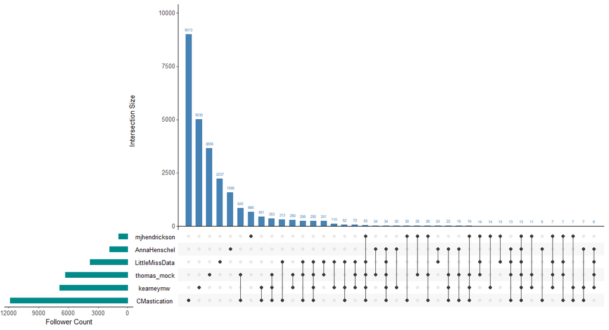

## But wait - there’s more!

For a full list of what’s included in the data pull, go to the [Tweet Data Dictionary](https://developer.twitter.com/en/docs/tweets/data-dictionary/overview/tweet-object.html)

A few of interest:

- `created_at` = UTC time of Tweet
- `text` = content of the Tweet
- `source` = utility used to post the Tweet
- `is_retweet` = TRUE/FALSE if this was a re-tweet
- `favorite_count` = number of times the Tweet was favorited
- `retweet_count` = number of times the Tweet was re-tweeted
- `hashtags` = string of all hashtags used
- `urls_url` = string of all urls
- `mentions_screen_name` = string of screen_names mentioned
- Fields on re-tweets, geolocation, user info

## All available fields

```r
as_tibble(colnames(search_tweets("#rladies", n = 1, include_rts = FALSE)))
```

| value |
| --- |
| user_id |
| status_id |
| created_at |
| screen_name |
| text |
| source |
| display_text_width |
| reply_to_status_id |
| reply_to_user_id |
| reply_to_screen_name |

[output cut: 80 more lines]

## Thank you

[@mjhendrickson](https://twitter.com/mjhendrickson)

[matthewjhendrickson](https://www.linkedin.com/in/matthewjhendrickson/)

mjhendrickson

This talk is freely distributed under the MIT License.  
(So is rtweet!)

## References

- Kearney MW (2019). “rtweet: Collecting and analyzing Twitter data.” Journal of Open Source Software, 4(42), 1829. doi: 10.21105/joss.01829, R package version 0.7.0, https://joss.theoj.org/papers/10.21105/joss.01829.
- Rudis, B (2018). “21 Recipes for Mining Twitter with rtweet” https://rud.is/books/21-recipes/
- Ellis, Laura (2019). “Set Analysis: A face off between Venn diagrams and UpSet plots.” https://www.littlemissdata.com/blog/set-analysis
- Kearney MW (2018). “R: Collecting and Analyzing Twitter Data.” - Specifically Slide 36 on SNA. https://github.com/mkearney/nicar_tworkshop
- Headshot by [Maureen Porto Photography](https://www.maureenporto.com/)
- No way gif by https://memecrunch.com/meme/C0QML/no-way
- Social media icons by https://iconmonstr.com/
- Twitter Data Dictionary https://developer.twitter.com/en/docs/tweets/data-dictionary/overview/tweet-object.html